# Answers to Exercises - Chapter 4

### c) Plot Prior, Likelihood, Posterior for Each Employee

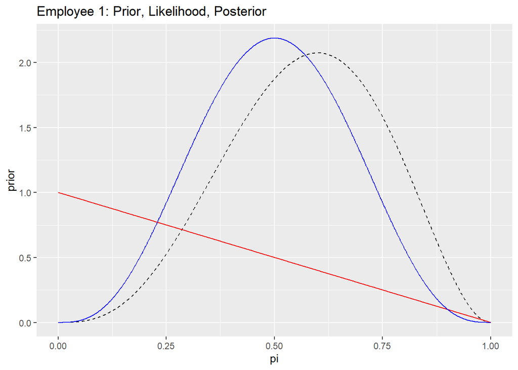

```r
library(ggplot2)

df <- data.frame(
  pi = seq(0, 1, length.out = 1000)
) %>%
  mutate(
    prior = dbeta(pi, 4, 3),
    like1 = dbinom(0, 1, pi),
    post1 = dbeta(pi, 4, 4),
    like2 = dbinom(3, 10, pi),
    post2 = dbeta(pi, 7, 10),
    like3 = dbinom(20, 100, pi),
    post3 = dbeta(pi, 24, 83)
  )

ggplot(df, aes(x = pi)) +
  geom_line(aes(y = prior), color = "black", linetype = "dashed") +
  geom_line(aes(y = like1), color = "red") +
  geom_line(aes(y = post1), color = "blue") +
  labs(title = "Employee 1: Prior, Likelihood, Posterior")
```

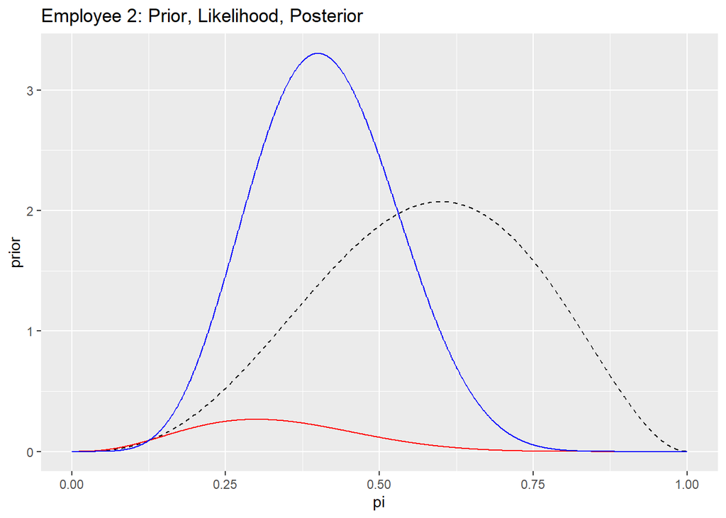

```r
ggplot(df, aes(x = pi)) +
  geom_line(aes(y = prior), color = "black", linetype = "dashed") +
  geom_line(aes(y = like2), color = "red") +
  geom_line(aes(y = post2), color = "blue") +
  labs(title = "Employee 2: Prior, Likelihood, Posterior")
```

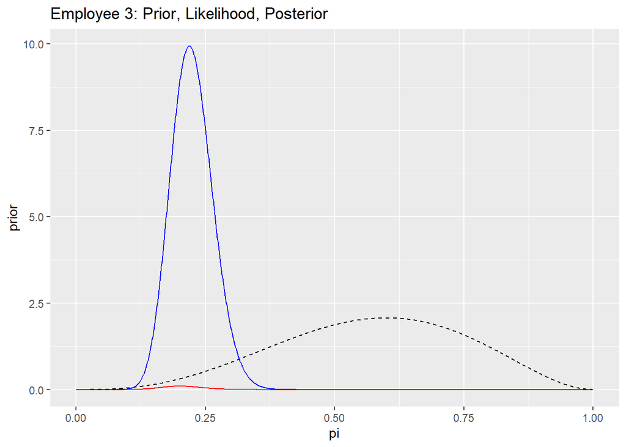

```r
ggplot(df, aes(x = pi)) +
  geom_line(aes(y = prior), color = "black", linetype = "dashed") +
  geom_line(aes(y = like3), color = "red") +
  geom_line(aes(y = post3), color = "blue") +
  labs(title = "Employee 3: Prior, Likelihood, Posterior")
```

### d) Summary and Comparison

- All three employees share the same prior (Beta(4,3)).
- Employee 1 has very limited data (1 trial), so the posterior (Beta(4,4)) remains close to the prior.
- Employee 2 has more data; their posterior shifts toward $\pi = 0.3$.
- Employee 3, with much more data, shows the most dramatic update, with a posterior centered near $\pi = 0.2$.

**Conclusion:** With increasing data, the influence of the prior diminishes, and the posterior is driven more by the data.